# Algorithm Class 3 - Lecture 2

Recursion I and Sorting Algorithms

May/27/2019

# 1 Recursion I

Key Knowledge for Recursion:

1. On the surface level: function calls itself
2. In the deep level: Boil down a big problem to a smaller ones (size n depends on size n-1, or n-2 or … n/2)
3. **Implementation:**
   1. **Base case:** smallest problem to solve
   2. **Recursive rule:** how to make the problem smaller (if we can resolve the same problem but with a smaller size, then what is left to do for the current problem size n)

Iterative way (step by step, e.g., while loop, for loop) v.s. Recursive way

## 1.1 Example 1: Fibonacci Sequence

- Base case: F(0) = 0; F(1) = 1;
- Recursive rule: F(n) = F(n-1) + F(n-2);

```java
//Calculating Fibonacci value
int fibo (int n) {
  // Base case (check whether need to stop when entering the function)
  if (n == 0) {
    return 0;
  } else if (n == 1) {
    return 1;
  }
  return fibo(n-1) + fibo(n-2); // Recursive rule
}
```

```
            F(4)             O(1)
          /      \
      F(3)        F(2)       O(2)
      /  \        /  \
   F(2)  F(1)  F(1)  F(0)    O(4)
   /  \
F(1)  F(0)                   ...
```

- Time = O($1+2+4+8+\cdots+2^n$) = O($2^n$)
  - Trick: the sum of all nodes above the last layer is smaller than the node number of the last layer, so we can just look at the node number of the last layer, which is $2^n$.

**Call Stack:** can be regarded as a **global accessible information** that tells you what happened before each **break point** in each level

- Space = O($n$)
  - It is proportional to the level of the recursion tree in this case, since each recursion function call only need O($1$) space.

## 1.2 Example 2: a to the b-th power

How to calculate $a^b$ (where a is an integer and b is also an integer, we do not care about the corner case where a = 0 or b < 0 for now)?

**Solution 0:**

- $a^b=a^{b-1}\times a$

```java
public int pow(int a, int b) {
  if (b == 0) {
    return 1; // base case
  }
  return a * pow(a, b - 1);
}
```

```
2^1000
2^999
2^998
 ...
 2^0
```

- Time = O($b$)
- Space = O($b$)

**Solution 1:**

```java
public int pow(int a, int b) {
  if (b == 0) {
    return 1;
  }
  else if (b == 1) {
    return a;
  }

  int mid = b / 2;
  return pow(a, mid) * pow(a, b - mid);
}
```

[output not shown]

- Time = $1+2+2^2+\cdots+2^{\log_2(b)}$ = O($b$)
- Space = O($\log(b)$)

**Solution 2:**

- $\text{half}=a^{\frac{b}{2}}$
- $a^b=\text{half}\times\text{half}$, even or odd

```java
public int pow(int a, int b) {
  if (b == 0) {
    return 1;
  }
  int half = pow(a, b / 2);
  if (b % 2 == 0) {
    return half * half;
  } else {
    return a * half * half;
  }
}
```

- Time = O($\log(b)$)
- Space = O($\log(b)$)

# 2 How to explain your code

A complete answer will include the following:

1. Document your assumptions.
2. Explain your approach and how you intend to solve the problem.
3. Provide code comments where applicable.
4. Explain the big-O run time complexity of your solution. Justify your answer.
5. Identify any additional data structures you used and justify why you used them.
6. Only provide your best answer to each part of the question.

# 3 Sorting Algorithms

1. What are sorting algorithms?
   1. Selection sort
   2. Merge sort
   3. Quick sort
   4. …
2. What are they good for?
   1. More general scope are covered
   2. Combined with system design (Discussed in System Design I)
   3. When solving a design problem. When should I use Merge sort vs Quick sort, for instance?
3. How thorough should I know about them and/or use them?

## 3.1 Selection Sort

### 3.1.1 Example

```
int a[i] = {-1, -3, 7, 4} --> {-3, -1, 4, 7} ascending order
```

- iteration 1: find global min -3

```
{-1, -3, 7, 4} --> -3 {-1, 7, 4}
```

- iteration 2: find global min in the rest

```
-3 {-1, 7, 4} --> -3 -1 {7, 4}
```

- iteration 3: find global min in the rest

```
-3 -1 {7, 4} --> -3 -1 4 {7}
```

```java
// selection sort an array a[] with size n
void selectionSort(int[] a, int n) {
  for (int i = 0; i < n - 1; i = i + 1) { // outer loop: how many iterations
    int globalMin = i;
    for (int j = i + 1; j < n; j = j + 1) { // inner loop: find the global min from the rest elements
      if (a[j] < a[globalMin]) {
        // record the index of the smallest element
        globalMin = j;
      }
    }
    // swap the global min (a[globalMin]) with a[i]
    int temp = a[i];
    a[i] = a[globalMin];
    a[globalMin] = temp;
  }
}
```

- Time: O($n^2$)
- Space: O($1$)

### 3.1.2 Question 1: 舉一反二

Given an array stored in Stack 1, how to sort the numbers by using additional two stacks (will be discussed later in stack class)

- Stack 1 (input)
- Stack 2 (buffer)
- Stack 3 (output)

```
Stack 1: [1 3 2 4]
Stack 2: []
Stack 3: []

---

Stack 1: [1 3 2]
Stack 2: [4]
Stack 3: []

globalMin = 4

---

Stack 1: [1 3]
Stack 2: [4 2]
Stack 3: []

globalMin = 2

---

Stack 1: [1]
Stack 2: [4 2 3]
Stack 3: []

globalMin = 2

---

Stack 1: []
Stack 2: [4 2 3 1]
Stack 3: []

globalMin = 1

---

Stack 1: []
Stack 2: [4 2 3]
```

[output cut: 16 more lines]

```
Stack 3: [1]

globalMin = 1

---

Stack 1: [3 2 4]
Stack 2: []
Stack 3: [1]

globalMin = 1

---

...
```

If there are duplicate elements, use a counter to record the number of `globalMin`.

### 3.1.3 Question 2: 舉一反三

What if only 1 additional stack can be used?

- Stack 1 (input)
- Stack 2 (buffer + output)

*見Class 4: Queue and Stack*

## 3.2 Merge Sort

### 3.2.1 Example

```
a[n] = 3,1,5,7,9,          8,6,4,2,0

       1 3 5 7 9           0 2 4 6 8
       i                   j

result = 0 1 2 3 4 5 6 7 8 9
```

```
      3,1,5,7,9,8,6,4,2,0
        /            \
     31579          86420        O(1)
     /   \          /   \
   315    79      864    20      O(2)
   / \    /\      / \    /\
 31   5  7  9   86   4  2  0     O(4)
 /\   |  |  |   /\   |  |  |     ...
3  1  5  7  9  8  6  4  2  0     O(n/2)
========================================
 13   5  7  9   68   4  2  0     O(n)
   \ /    \/      \ /    \/
   135    79      468    02      O(n)
     \   /          \   /
     13579          02468        O(n)
        \            /
          0123456789             O(n)
```

Time complexity about the line = 1 + 2 + … + n/2 = O($\frac{n}{2}$) = O($n$)

Time complexity below the line = O($n\log{n}$)

- Total time: O($n+n\log{n}$) = O($n\log{n}$)
- Space: O($n$)

```java
// For demonstration purposes only. This is NOT the recommended implementation. See practice class & Java solutions.
// main function that calls merge_sort
// left: the left index of the sub list
// right: the right index of the sub list

List<Integer> mergeSort(int[] a, int left, int right) {
  if (left == right) {  // base case
    return Arrays.asList(a[left]);
  }

  // recursive rule is below
  int mid = left + (right - left) / 2;
  List<Integer> soluLeft = mergeSort(a, left, mid);
  List<Integer> soluRight = mergeSort(a, mid + 1, right);
  return combine(soluLeft, soluRight);  //誰小移誰
}
```

### 3.2.2 Question 3: 舉一反二

Could we use Merge Sort to sort a linked list? What is the time complexity if so?

- Yes. Time complexity is the same, O($n\log{n}$).
- Space complexity is O($\log{n}$).

### 3.2.3 Question 4: 舉一反二

Given a string “A1B2C3D4”, how to convert it to another string “ABCD1234”?

```
           A1B2C3D4
        /            \
     A1B2            C3D4
   /      \        /      \
  A1      B2      C3      D4
 /  \    /  \    /  \    /  \
A    1  B    2  C    3  D    4
================================
  A1      B2      C3      D4
   \      /        \      /
     AB12            CD34
        \            /
           ABCD1234
```

### 3.2.4 Question 5: 舉一反三

Convert string “ABCD1234” to “A1B2C3D4”. Please do it in place. (In place means do it with original input string rather than use an additional string.)

大致講解, String Class會講細節.

### 3.2.5 Question 6: 舉一反三

How to sort 1TB data with multiple machines using Map-Reduced? Note: every single data can be seen as a string or byte[]. E.g. aaa < abc.

**Solution 1:**

- 把原有的數據分佈到多個節點上分別排序, 最後歸并排序.

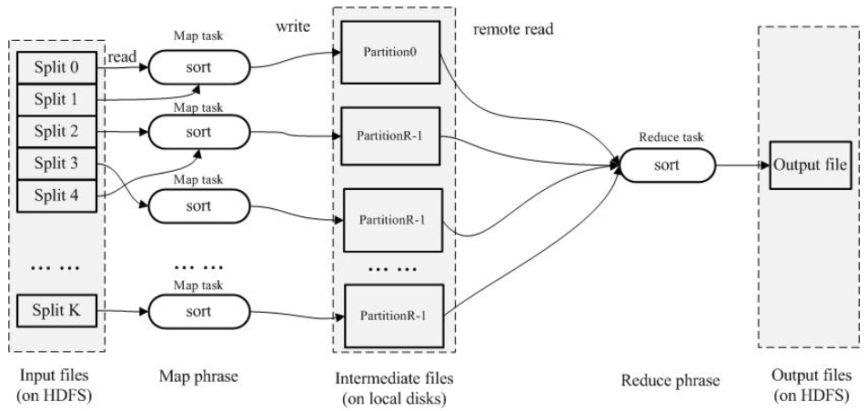

Bottle Neck: Merge Sort. A single reducer needs to process all the data.

**Solution 2:**

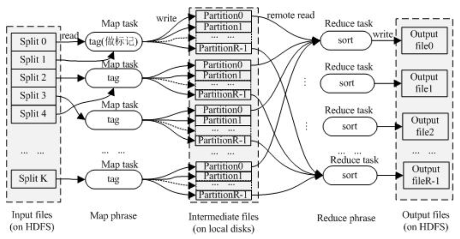

### 3.2.6 Question X

Count-array problem: Given an array A[N] with all positive integers from [1, …, N]. How to get an array B[N] such that B[i] represents how many elements A[j] (j>1) in array A[] that are smaller than A[i]. For example, given A[N] = {4, 1, 3, 2}, we should get B[N] = {3, 0, 1, 0}. Requirement: Time = O($n\log(n)$).

Key property: 在$\log(n)$層中, combine function能夠讓每個element都會和其他所有的元素compare至少一次. 總的時間複雜度依然是$n\log(n)$.

## 3.3 Quick Sort

Basic Idea: Two pointers (i, j), three areas (a, b, c)

1. [0, i): all numbers to the LHS of i (exclusive) are smaller than pivot.
2. [i, j]: unknown area to explore (including i and j).
3. (j, n-1]: all numbers to the RHS of j (exclusive) are greater or equal to pivot.

### 3.3.1 Example

Initial state: 1 9 8 5 3. Say pivot = 5.

```
Step 0: (input)
1  9  8  5  3
pivot == 5 (randomly selected)

---

Step 1:
swap the pivot to the right end, set i and j
1  9  8  3  5
i        j

now: a []
     b [1, 9, 8, 3]
     c []

---

Step 2:
input[i] < pivot, so i++
1  9  8  3  5
   i     j

now: a [1]
     b [9, 8, 3]
     c []

---

Step 3:
input[i] > pivot, so swap(input[i], input[j]), j--
1  3  8  9  5
   i  j

now: a [1]
     b [3, 8]
     c [9]

---

Step 4:
```

[output cut: 13 more lines]

```
   j  i    n-1

now: a [1, 3]
     b []
     c [8, 9]

---

Step 6:
i > j, put pivot to the right position, swap(input[i], input[n-1])
1  3  (5)  9  8

---

...
```

All numbers on the LHS are smaller than the pivot, and all numbers on the RHS are larger than the pivot. These are the details in one QuickSort process.

Recursive Rule:

1. QuickSort all numbers to the left of 5
2. QuickSort all numbers to the right of 5

### 3.3.2 Question 7: 舉一反二

What is the worst case scenario for quick sort? Can you provide an example?

- O($n^2$)

```
step 0: xxxxxxxxxxxxxxxP0    n -> n-1
step 1: xxxxxxxxxxxxxxP1   n-1 -> n-2
...
```

n steps:

- worst case time = n + n-1 + n-2 + … + 1 = O($n^2$), space = O($n$)
- average case time = O($n\log(n)$), space = O($\log(n)$)

### 3.3.3 Question 8: 舉一反二 Array Shuffling

Given an array with integers, move all “0”s to the right-end of the array.

[output not shown]

Initialization (2 pointers, 3 areas):

1. i = 0: all numbers to the LHS of i (not including i) are all “non-zero”s
2. [i, j]: unknown area to explore
3. j = size - 1: all numbers to the RHS of j (not including j) are all “zero”s

```
Step 0:
1   0  -4  -5   0   2   3
i                       j

---

Step 1:
input[i] != 0, so i++
1   0  -4  -5   0   2   3
    i                   j

---

Step 2:
input[i] == 0, so swap(input[i], input[j]), j--
1   3  -4  -5   0   2   0
    i               j

---

Step 3:
1   3  -4  -5   0   2   0
        i           j

---

Step 4:
1   3  -4  -5   0   2   0
            i       j

---

Step 5:
1   3  -4  -5   0   2   0
                i   j

---

Step 6:
1   3  -4  -5   2   0   0
                ij

---

Step 7:
1   3  -4  -5   2   0   0
                j   i
```

### 3.3.4 Question 9: 舉一反三 Rainbow Sort

```
input:  abcccabbcbbacaa
output: aaaaabbbbbccccc
```

Initialization (3 pointer, 4 areas):

1. i = 0: all letters to the LHS of i (not including i) are all “a”s
2. j = 0: all letters in [i, j) (including i, but not including j) are all “b”s
3. [j, k]: unexplored area (including j and k)
4. k = n - 1: all letters to the RHS of k (not including k) are all “c”s

Case 1: if input[j] == a, swap(i, j), i++, j++

Case 2: if input[j] == b, j++

Case 3: if input[j] == c, swap(j ,k), k–

- Time: O($n$)
- Space: O($1$)

### 3.3.5 舉一反四 Four Colors or even more

Initialization (4 pointer, 5 areas)

Systematic Way of Thinking